# Práctica guiada 4 - Módulo 3

Regresión logística

Diplomatura en Ciencias Sociales Computacionales y Humanidades Digitales (IDAES-UNSAM)

Carolina Pradier y Guido Weksler

```r
library(tidyverse)
library(tidymodels)
library(gtsummary)
library(modelsummary)
library(gt)

#options(dplyr.summarise.inform = FALSE)
options(scipen = 999)
```

# 1 Regresión logística

## 1.1 Introducción

Operemos con [Tidymodels](https://www.tidymodels.org/) para hacer un modelo de clasificación con el método de la regresión logística. Usaremos nuestra base de juguete de 200 datos ficticios, con la variable objetivo **realiza_trabajo_domestico**. Por ahora, tomaremos únicamente como variables explicativas las horas trabajadas en el mercado y el ingreso total familiar.

Visualicemos previamente estos datos.

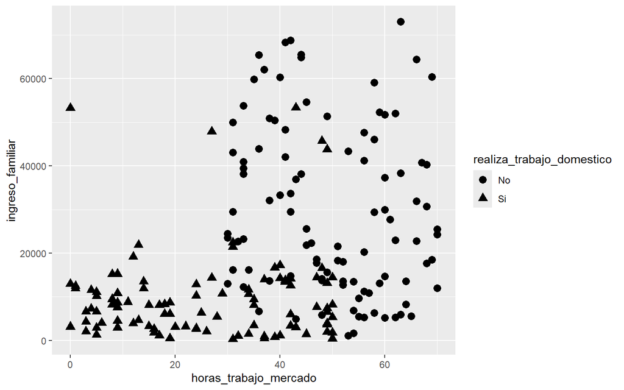

```r
base_juguete <- readRDS(file = "fuentes/eut_juguete_clase4.RDS")
#Ruta puede variar si se usa project módulo o project clase 4


ggplot(base_juguete,aes(x = horas_trabajo_mercado,
                        y = ingreso_familiar,
                        shape = realiza_trabajo_domestico))+
  geom_point(size = 3)
```

Ahora vamos a repasar los pasos necesarios para correr el modelo. Luego, discutamos la interpretación de los coeficientes y las métricas de ajuste.

## 1.2 Seteo el tipo de modelo

En formato tidy, comienzo especificando el tipo de modelo. En este caso, **logistic_reg()**. De ser necesario puedo especificar con **set_mode()** el modo del modelo (qué tipo de predicción tiene el outcome, numérica o categórica) Luego, especifico cual es el sistema que utilizaré para estimar el modelo con la función **set_engine()** (en muchos casos responde al paquete que voy a usar para correr el modelo).

```r
log_model <- logistic_reg() %>% #Defino el tipo de modelo
  set_mode("classification") %>%  #el modo (regresión o clasificación)
  set_engine("glm") #el motor en este caso es glm ("Generalized linear models")
```

## 1.3 Fiteo (entreno/estimo) el modelo

Tomo la especificación anterior y explicito que variables usaré y de que dataset.

*Importante:* La variable objetivo `realiza_trabajo_domestico` **debo convertirla en factor** para correr una regresión logistica (es decir, que sea una variable con categorías). El primer nivel del factor va a ser el caso base, que en general queremos que sea “No” para facilitar la interpretación.

Por otra parte, si van a utilizar funciones que calculan métricas derivadas de la matriz de confusión es muy importante que las **categorías estén ordenadas con el valor positivo (“Si”) como primer nivel y el negativo (“No”) como el segundo nivel**. Así que lo vamos a ir cambiando.

```r
base_para_modelar <- base_juguete %>%
  mutate(realiza_trabajo_domestico = factor(realiza_trabajo_domestico,levels = c("No","Si")))

#Lo entreno con los datos
log_fit <- log_model %>%
  fit(realiza_trabajo_domestico ~ horas_trabajo_mercado +
                                  ingreso_familiar,
      data = base_para_modelar)
```

## 1.4 Veamos resultados de los parámetros estimados

Si bien podemos correr directo el objeto **log_fit** para ver los resultados, la función `tidy()` nos transforma los coeficientes estimados (y también su desvío estándar, z-statistic y p.valor) a un formato data_frame. Para visualizarlo de forma más prolija usamos aquí también la función `gt()` del paquete homónimo.

```r
log_fit %>%
  tidy() %>%
  gt()
```

| term | estimate | std.error | statistic | p.value |
| --- | --- | --- | --- | --- |
| (Intercept) | 7.00600456351 | 1.12337884518 | 6.236547 | 0.000000000447336 |
| horas_trabajo_mercado | -0.13049264828 | 0.02235002378 | -5.838591 | 0.000000005264412 |
| ingreso_familiar | -0.00009948635 | 0.00001938386 | -5.132431 | 0.000000286023370 |

El paquete `modelsummary` y su función homónima nos arroja también datos sobre la bondad de ajuste del modelo. Tenemos medidas como el Akaike information criterion (AIC) y el Bayesian Information Criterion (BIC). Una herramienta interesante es que podemos pasar una lista de modelos y comparar entre ellos. Solo para estos fines, entrenemos otro modelo que también incluye la variable de menores en el hogar.

```r
log_fit2 <- log_model %>%
  fit(realiza_trabajo_domestico ~ horas_trabajo_mercado +
                                  ingreso_familiar +
                                  menores_hogar,
      data = base_para_modelar)


modelsummary(
  list("logistica 2 predictores " = log_fit,
       "logistica 3 predictores" = log_fit2)
  )
```

|  | logistica 2 predictores | logistica 3 predictores |
| --- | --- | --- |
| (Intercept) | 7.006 | 5.406 |
|  | (1.123) | (1.225) |
| horas_trabajo_mercado | -0.130 | -0.131 |
|  | (0.022) | (0.026) |
| ingreso_familiar | -0.000 | -0.000 |
|  | (0.000) | (0.000) |
| menores_hogarSi |  | 2.684 |
|  |  | (0.553) |
| Num.Obs. | 200 | 200 |
| AIC | 131.4 | 104.1 |
| BIC | 141.3 | 117.3 |
| RMSE | 0.31 | 0.28 |

*Aclaración:* Dado que nos interesan más otro tipo de métricas, no veremos en detalle la estimación de medidas de bondad de ajuste como AIC y BIC. A los fines prácticos basta con tener noción de que:

- Su utilidad es para **comparar modelos** (la interpretación del AIC o BIC de 1 modelo en si mismo es irrelevante)
- Las fórmulas de AIC y BIC tienen la siguiente “pinta”: $xIC= flexibilidad-ajuste$.  
  Un término positivo que actúa como penalización a la flexibilidad del modelo (asociado a la cantidad de parametros o variables que utiliza). Un término restando asociado a la capacidad de ajuste del modelo (vinculada a la **máxima verosimilitud**, es decir, cuan cerca le paso a los valores reales con mi predicción de probabilidad)
- Al comparar dos modelos, son mejores los que tienen **menor valor de AIC o BIC**
- En el ejemplo anterior, a pesar de haber agregado flexibilidad en el 2do modelo (1 variable más), ganamos mucho en ajuste, por eso el AIC y BIC son más bajos.

## 1.5 Predicción

### 1.5.1 Aplicado sobre datos nuevos

Si queremos sólo obtener la predicción que nuestro modelo hará sobre nuevos datos, la función `predict()` requiere como imput un data.frame que contenga columnas nombradas igual que los predictores de nuestro modelo y devuelve, en el mismo orden, las predicciones para la variable Y.

```r
data_nueva <- data.frame(horas_trabajo_mercado = c(40,13),
                        ingreso_familiar = c(60000,10000))

log_fit %>%
  predict(new_data = data_nueva)
```

```
## # A tibble: 2 × 1
##   .pred_class
##   <fct>
## 1 No
## 2 Si
```

Una función que puede resultar todavía más útil que `predict()` es `augment()`. Al pasarle un modelo entrenado y un dataset para realizar predicciones, esta última añade a dicho dataset el valor de la clase predicha y también las probabilidades estimadas que respaldan dicha predicción

```r
log_fit %>%
  augment(new_data = data_nueva)
```

```
## # A tibble: 2 × 5
##   .pred_class .pred_No .pred_Si horas_trabajo_mercado ingreso_familiar
##   <fct>          <dbl>    <dbl>                 <dbl>            <dbl>
## 1 No            0.985    0.0150                    40            60000
## 2 Si            0.0132   0.987                     13            10000
```

### 1.5.2 Aplicado sobre el total de la base

Tomemos la función `augment()` para agregar a nuestro dataset **base_para_modelar** las probabilidades asignadas por nuestro modelo a cada uno de los casos, y por ende, la clase predicha.

Podemos usar las probabilidades para cambiar el umbral de clasificación.

```r
base_con_pred <- log_fit %>%
  augment(base_para_modelar) %>%
  mutate(prediccion_80 = ifelse(.pred_No > 0.8, yes = "No", no = "Si"))

base_con_pred
```

```
## # A tibble: 200 × 8
##    .pred_class .pred_No .pred_Si realiza_trabajo_domestico horas_trabajo_mercado
##    <fct>          <dbl>    <dbl> <fct>                                     <int>
##  1 No             0.805   0.195  No                                           56
##  2 Si             0.405   0.595  No                                           33
##  3 No             0.985   0.0147 No                                           36
##  4 No             0.965   0.0348 No                                           70
##  5 Si             0.288   0.712  No                                           43
##  6 Si             0.341   0.659  No                                           30
##  7 No             0.957   0.0431 No                                           39
##  8 No             0.858   0.142  No                                           51
##  9 No             0.937   0.0632 No                                           64
## 10 No             0.829   0.171  No                                           52
## # ℹ 190 more rows
## # ℹ 3 more variables: ingreso_familiar <dbl>, menores_hogar <chr>,
## #   prediccion_80 <chr>
```

# 2 Métricas de evaluación

## 2.1 Matriz de confusión

Sobre la base de los valores reales y los valores predichos calcular la matriz de confusión. Como adelantamos, necesitamos revertir el orden de los factores para que las funciones que nos calculan las métricas anden bien (sorry).

```r
# Aplicamos orden alternativo
base_metricas <- base_con_pred %>%
  mutate(realiza_trabajo_domestico = factor(realiza_trabajo_domestico,
                                            levels = c("Si","No")),
         .pred_class = factor(.pred_class,
                              levels = c("Si","No")))

matriz_confusion <- conf_mat(data = base_metricas ,
                             truth = realiza_trabajo_domestico,
                             estimate = .pred_class)

matriz_confusion
```

```
##           Truth
## Prediction Si No
##         Si 88 14
##         No 12 86
```

> ¿Quién se anima a leer estos resultados?

## 2.2 Métricas derivadas de la matriz

Accuracy, Sensitividad/Recall, Specificity y Precision

```r
accu <- accuracy(data = base_metricas,
            truth = realiza_trabajo_domestico,
            estimate =  .pred_class)

accu
```

```
## # A tibble: 1 × 3
##   .metric  .estimator .estimate
##   <chr>    <chr>          <dbl>
## 1 accuracy binary          0.87
```

- El modelo predice correctamente un 87.0% de los casos.

```r
sens <- sensitivity(base_metricas,truth = realiza_trabajo_domestico,estimate =  .pred_class)

spec <- specificity(base_metricas,truth = realiza_trabajo_domestico,estimate =  .pred_class)

prec <- precision(base_metricas,truth = realiza_trabajo_domestico,estimate =  .pred_class)

bind_rows(accu,sens,spec,prec)
```

```
## # A tibble: 4 × 3
##   .metric     .estimator .estimate
##   <chr>       <chr>          <dbl>
## 1 accuracy    binary         0.87
## 2 sensitivity binary         0.88
## 3 specificity binary         0.86
## 4 precision   binary         0.863
```

- De los casos positivos (que efectivamente realizan trabajo doméstico), el modelo predice bien un 88.00%.
- De los casos negativos (que no realizan trabajo doméstico), el modelo predice bien un 86.00%.
- De los casos que son clasificados como positivos, sólo un 86.27% . lo son.

Veamos esto de forma gráfica para tratar de entender como está operando nuestro modelo:  
En este gráfico utilizamos el parametro **shape** para distinguir el valor real de la variable objetivo (“No” o “Si”) y el **color** para mostrar las probabilidades de pertenecer a la clase “Si” estimadas por nuestro modelo.

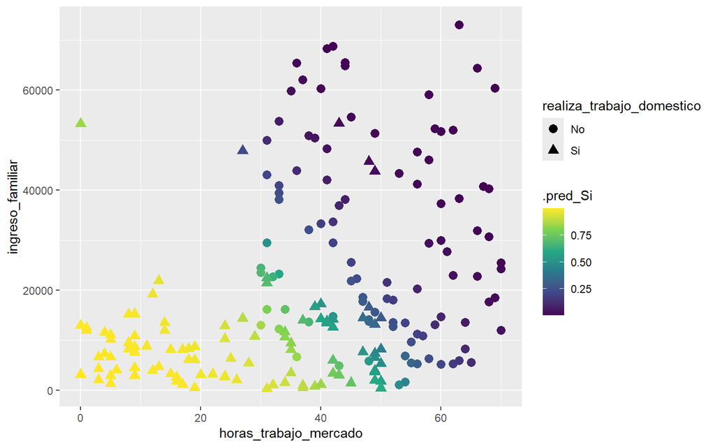

```r
ggplot(base_con_pred,aes(x = horas_trabajo_mercado,
                         y = ingreso_familiar,
                         shape = realiza_trabajo_domestico,
                         color = .pred_Si))+
  geom_point(size = 3)+
  scale_color_viridis_c()
```

En este otro utilizamos el **color** no para mostrar las probabildiades, sino para ver la clase predicha por nuestro modelo (lo que tenia probabilidad mayor a 0,5 queda como “Si”, los menores a 0,5 como “No”). Ver como la “decision boundary” parece ser líneal. (Podemos traducir decision boundary como frontera de decisión)

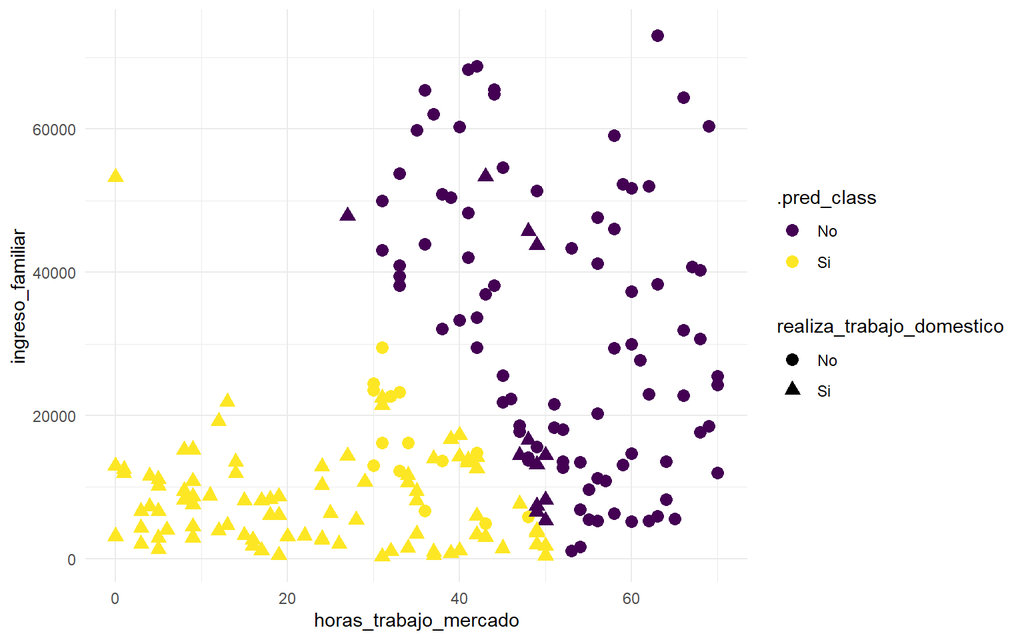

```r
ggplot(base_con_pred,aes(x = horas_trabajo_mercado,
                         y = ingreso_familiar,
                         shape = realiza_trabajo_domestico,
                         color = .pred_class))+
  geom_point(size = 3)+
  scale_color_viridis_d()+
  theme_minimal()
```

> El ejercicio anterior tiene un problema. Utilizamos para evaluar la performance del modelo los mismos datos que utilizamos para entrenarlo. Eso es potencialmente peligroso por posible **OVERFITTING**.

## 2.3 Train-test split

Hagamos un modelo nuevo con un split de la base original en test y train. Aclaración: Si queremos resultados replicables debemos **setear una semilla** con `set.seed()`, para guardar el mecanismo de pseudo-aleatorización que realiza la computadora.

### 2.3.1 Split

```r
set.seed(2024) #Cualquier cosa

base_split <-  initial_split(base_para_modelar, prop = 0.8)
base_train <-  training(base_split)
base_test <-  testing(base_split)
```

### 2.3.2 Fit

Estimamos el modelo con la base train.

```r
log_fit_train <- log_model  %>%
  fit(realiza_trabajo_domestico ~ horas_trabajo_mercado +
                                  ingreso_familiar,
      data = base_train)

log_fit_train %>% tidy()
```

```
## # A tibble: 3 × 5
##   term                    estimate std.error statistic      p.value
##   <chr>                      <dbl>     <dbl>     <dbl>        <dbl>
## 1 (Intercept)            7.44      1.37           5.42 0.0000000585
## 2 horas_trabajo_mercado -0.137     0.0268        -5.12 0.000000306
## 3 ingreso_familiar      -0.0000975 0.0000203     -4.80 0.00000158
```

### 2.3.3 Aplico predicciones a la base de testeo

Usamos el modelo para predecir, aplicándolo sobre la base test.

```r
base_test_con_pred <- log_fit_train %>%
  augment(new_data = base_test)

base_test_con_pred
```

```
## # A tibble: 40 × 7
##    .pred_class .pred_No .pred_Si realiza_trabajo_domestico horas_trabajo_mercado
##    <fct>          <dbl>    <dbl> <fct>                                     <int>
##  1 No             0.944 0.0557   No                                           39
##  2 Si             0.232 0.768    No                                           34
##  3 Si             0.429 0.571    No                                           48
##  4 Si             0.263 0.737    No                                           30
##  5 No             1.00  0.000372 No                                           66
##  6 Si             0.291 0.709    No                                           38
##  7 No             0.983 0.0168   No                                           53
##  8 No             0.692 0.308    No                                           33
##  9 No             0.833 0.167    No                                           42
## 10 No             0.903 0.0972   No                                           60
## # ℹ 30 more rows
## # ℹ 2 more variables: ingreso_familiar <dbl>, menores_hogar <chr>
```

### 2.3.4 Matriz de confusión

Ahora podemos calcular las métricas sobre la base de los valores reales y los valores predichos. Estas predicciones se hicieron sin usar los valores reales para estimar.

```r
matriz_confusion_test<- conf_mat(data = base_test_con_pred,
                                 truth = realiza_trabajo_domestico,
                                 estimate =.pred_class)

matriz_confusion_test
```

```
##           Truth
## Prediction No Si
##         No 13  0
##         Si  7 20
```

# 3 Espacio de práctica (en clase)

Supongan que les solicitan armar un modelo con una sola variable predictora de las disponibles. Entrenen *con un mismo training set* 2 modelos con un solo predictor y evalúen cómo pronostica la realización de TDNR en el *test set*. Pueden calcular solo el **accuracy**.

# 4 Ejercicio con datos reales

- Levantemos la base de datos reales llamada **base_EAUH_TNR** (tiene un pre-procesamiento de seleccion y recategorización de algunas variables).
- Creamos allí la variable dicotómica “realiza_trabajo_doméstico” que tome los valores “Si” y “No” a partir de la variable original de **TIEMPO_TDNR**. *Recordatorio*: Necesitamos crearla como un factor, y el primer nivel es la referencia.
- Separamos el dataset en train y test.
- Utilizamos el set de training para construir 2 modelos de regresión logistica con 3 variables predictoras cada uno.
- Comparamos la **performance** de ambos modelos para predecir en el dataset de testing.

Traemos los datos y hacemos el split.

```r
# Base de datos
#Ruta puede variar si se usa project módulo o project clase 4
base_real <- readRDS(file = "fuentes/base_EAUH_TNR.RDS") %>%
  mutate(realiza_trabajo_domestico = factor(ifelse(TIEMPO_TDNR != 0,
                                                   yes = "Si",
                                                   no = "No"),
                                            levels = c("No","Si"))) %>%
  rename("sexo"=CH04)

# Train-test split
set.seed(123)
base_split <- initial_split(base_real)
base_train <- training(base_split)
base_test <- testing(base_split)
```

Estimamos los modelos.

```r
# Elijo modelo
log_model <- logistic_reg() %>%
  set_mode("classification") %>%
  set_engine("glm")

# Estimo con fórmula 1
log_fit <- log_model %>%
  fit(realiza_trabajo_domestico ~ horas_mercado +
                                  menores_hogar +
                                  NIVEL_ED,
      data = base_train)

# Estimo con fórmula 2
log_fit2 <- log_model %>%
  fit(realiza_trabajo_domestico ~ horas_mercado +
                                  ingreso_indiv +
                                  sexo,
      data = base_train)
```

Inspeccionamos los resultados.

```r
log_fit %>%
  tidy()
```

```
## # A tibble: 9 × 5
##   term                                    estimate std.error statistic   p.value
##   <chr>                                      <dbl>     <dbl>     <dbl>     <dbl>
## 1 (Intercept)                               0.981   0.0350       28.1  1.95e-173
## 2 horas_mercado                            -0.0156  0.000447    -35.0  8.86e-268
## 3 menores_hogar                             0.131   0.00899      14.6  1.96e- 48
## 4 NIVEL_EDPrimaria Completa                 0.317   0.0404        7.85 4.17e- 15
## 5 NIVEL_EDSecundaria Incompleta             0.240   0.0417        5.76 8.32e-  9
## 6 NIVEL_EDSecundaria Completa               0.509   0.0409       12.4  1.50e- 35
## 7 NIVEL_EDSuperior Universitaria Incompl…   0.341   0.0448        7.63 2.40e- 14
## 8 NIVEL_EDSuperior Universitaria Completa   0.859   0.0465       18.5  2.45e- 76
## 9 NIVEL_EDSin instrucción                  -0.494   0.0887       -5.56 2.63e-  8
```

```r
log_fit2 %>%
  tidy()
```

```
## # A tibble: 4 × 5
##   term             estimate  std.error statistic  p.value
##   <chr>               <dbl>      <dbl>     <dbl>    <dbl>
## 1 (Intercept)    0.381      0.0211         18.1  5.53e-73
## 2 horas_mercado -0.00237    0.000512       -4.64 3.44e- 6
## 3 ingreso_indiv  0.00000949 0.00000260      3.64 2.68e- 4
## 4 sexoMujer      1.80       0.0257         69.8  0
```

```r
modelsummary::modelsummary(
  list("modelo 1 " = log_fit,
       "modelo 2" = log_fit2)
  )
```

|  | modelo 1 | modelo 2 |
| --- | --- | --- |
| (Intercept) | 0.981 | 0.381 |
|  | (0.035) | (0.021) |
| horas_mercado | -0.016 | -0.002 |
|  | (0.000) | (0.001) |
| menores_hogar | 0.131 |  |
|  | (0.009) |  |
| NIVEL_EDPrimaria Completa | 0.317 |  |
|  | (0.040) |  |
| NIVEL_EDSecundaria Incompleta | 0.240 |  |
|  | (0.042) |  |
| NIVEL_EDSecundaria Completa | 0.509 |  |
|  | (0.041) |  |
| NIVEL_EDSuperior Universitaria Incompleta | 0.341 |  |
|  | (0.045) |  |
| NIVEL_EDSuperior Universitaria Completa | 0.859 |  |
|  | (0.046) |  |
| NIVEL_EDSin instrucción | -0.494 |  |
|  | (0.089) |  |
| ingreso_indiv |  | 0.000 |
|  |  | (0.000) |
| sexoMujer |  | 1.797 |
|  |  | (0.026) |
| Num.Obs. | 48954 | 48954 |
| AIC | 53326.3 | 48381.5 |
| BIC | 53405.5 | 48416.7 |
| RMSE | 0.43 | 0.40 |

Si queremos ver cómo quedó codificada la variable categórica NIVEL_ED podemos usar `contrasts()`

```r
contrasts(base_train$NIVEL_ED)
```

```
##                                                  Primaria Completa
## Primaria Incompleta (incluye educación especial)                 0
## Primaria Completa                                                1
## Secundaria Incompleta                                            0
## Secundaria Completa                                              0
## Superior Universitaria Incompleta                                0
## Superior Universitaria Completa                                  0
## Sin instrucción                                                  0
## Ns./Nr.                                                          0
##                                                  Secundaria Incompleta
## Primaria Incompleta (incluye educación especial)                     0
## Primaria Completa                                                    0
## Secundaria Incompleta                                                1
## Secundaria Completa                                                  0
## Superior Universitaria Incompleta                                    0
## Superior Universitaria Completa                                      0
## Sin instrucción                                                      0
## Ns./Nr.                                                              0
##                                                  Secundaria Completa
## Primaria Incompleta (incluye educación especial)                   0
## Primaria Completa                                                  0
## Secundaria Incompleta                                              0
## Secundaria Completa                                                1
## Superior Universitaria Incompleta                                  0
## Superior Universitaria Completa                                    0
## Sin instrucción                                                    0
## Ns./Nr.                                                            0
##                                                  Superior Universitaria Incompleta
## Primaria Incompleta (incluye educación especial)                                 0
## Primaria Completa                                                                0
## Secundaria Incompleta                                                            0
## Secundaria Completa                                                              0
## Superior Universitaria Incompleta                                                1
## Superior Universitaria Completa                                                  0
## Sin instrucción                                                                  0
## Ns./Nr.                                                                          0
##                                                  Superior Universitaria Completa
## Primaria Incompleta (incluye educación especial)                               0
## Primaria Completa                                                              0
## Secundaria Incompleta                                                          0
## Secundaria Completa                                                            0
## Superior Universitaria Incompleta                                              0
## Superior Universitaria Completa                                                1
## Sin instrucción                                                                0
## Ns./Nr.                                                                        0
##                                                  Sin instrucción Ns./Nr.
## Primaria Incompleta (incluye educación especial)               0       0
## Primaria Completa                                              0       0
## Secundaria Incompleta                                          0       0
## Secundaria Completa                                            0       0
## Superior Universitaria Incompleta                              0       0
## Superior Universitaria Completa                                0       0
## Sin instrucción                                                1       0
## Ns./Nr.                                                        0       1
```

```r
log_fit_test <- log_fit %>%
  augment(base_test) %>%
  rename(pred_m1 = .pred_class)

log_fit2_test <- log_fit2 %>%
  predict(base_test) %>%
  rename(pred_m2 = .pred_class)

base_2modelos <- log_fit_test %>%
  bind_cols(log_fit2_test)

base_2modelos %>% conf_mat(truth = realiza_trabajo_domestico,estimate = pred_m1)
```

```
##           Truth
## Prediction    No    Si
##         No    50    73
##         Si  4066 12130
```

```r
base_2modelos %>% conf_mat(truth = realiza_trabajo_domestico,estimate = pred_m2)
```

```
##           Truth
## Prediction    No    Si
##         No     0     0
##         Si  4116 12203
```

> ¿Que les llama la atención al ver la matriz de confusión?

# 5 Ejercicio de balanceo de clases

En vez de tomar toda la base de datos para dividir en train y test, hacemos una muestra balanceada para evitar que un clasificador trivial (como predecir que todos hacen trabajo doméstico) de buenos resultados. Vemos que en la base real hay unas 16.000 personas que no realizan trabajo doméstico, así que ese sería el máximo de nuestra muestra. Tomemos 15.000 de cada clase.

```r
table(base_real$realiza_trabajo_domestico)
```

```
##
##    No    Si
## 16301 48972
```

```r
base_balanceada <- base_real %>%
  group_by(realiza_trabajo_domestico) %>%
  sample_n(size = 15000) %>%
  ungroup()
```

Chequeamos que haya funcionado.

```r
table(base_balanceada$realiza_trabajo_domestico)
```

```
##
##    No    Si
## 15000 15000
```

Ahora podemos hacer el split y estimar el modelo. Podemos una “b” por “balanceada”.

```r
# Split
set.seed(1234)
base_b_split <- initial_split(base_balanceada)
base_b_train <- training(base_b_split)
base_b_test <- testing(base_b_split)

# Model
log_model <- logistic_reg() %>% #Defino el tipo de modelo
  set_mode("classification") %>%  #el modo (regresión o clasificación)
  set_engine("glm")

# Fit
log_fit_1b <- log_model %>%
  fit(realiza_trabajo_domestico ~ horas_mercado +
                                  menores_hogar +
                                  NIVEL_ED,
      data = base_b_train)

log_fit_2b <- log_model %>%
  fit(realiza_trabajo_domestico ~ horas_mercado +
                                  ingreso_indiv +
                                  sexo,
      data = base_b_train)

log_fit_1b %>%
  tidy()
```

```
## # A tibble: 9 × 5
##   term                                    estimate std.error statistic   p.value
##   <chr>                                      <dbl>     <dbl>     <dbl>     <dbl>
## 1 (Intercept)                              -0.0928  0.0456       -2.04 4.18e-  2
## 2 horas_mercado                            -0.0162  0.000589    -27.6  3.54e-167
## 3 menores_hogar                             0.131   0.0112       11.8  5.60e- 32
## 4 NIVEL_EDPrimaria Completa                 0.314   0.0525        5.97 2.39e-  9
## 5 NIVEL_EDSecundaria Incompleta             0.186   0.0542        3.44 5.91e-  4
## 6 NIVEL_EDSecundaria Completa               0.505   0.0532        9.49 2.34e- 21
## 7 NIVEL_EDSuperior Universitaria Incompl…   0.298   0.0580        5.13 2.86e-  7
## 8 NIVEL_EDSuperior Universitaria Completa   0.870   0.0594       14.7  1.30e- 48
## 9 NIVEL_EDSin instrucción                  -0.487   0.121        -4.01 6.02e-  5
```

```r
log_fit_2b %>%
  tidy()
```

```
## # A tibble: 4 × 5
##   term             estimate  std.error statistic   p.value
##   <chr>               <dbl>      <dbl>     <dbl>     <dbl>
## 1 (Intercept)   -0.721      0.0283        -25.5  2.19e-143
## 2 horas_mercado -0.00244    0.000680       -3.59 3.27e-  4
## 3 ingreso_indiv  0.00000989 0.00000346      2.86 4.23e-  3
## 4 sexoMujer      1.81       0.0320         56.6  0
```

```r
log_fit_1b_test <- log_fit_1b %>%
  augment(base_b_test) %>%
  select(realiza_trabajo_domestico,.pred_class) %>%
  rename(pred_m1 = .pred_class)

log_fit_2b_test <- log_fit_2b %>%
  predict(base_b_test) %>%
  rename(pred_m2 = .pred_class)

base_2modelos_b <- log_fit_1b_test %>%
  bind_cols(log_fit_2b_test)
```

Para calcular las métricas de la matriz de confusión, primero tenemos que dar vuelta el orden de los niveles en los factores.

```r
base_2modelos_b <- base_2modelos_b %>%
  mutate(realiza_trabajo_domestico = factor(realiza_trabajo_domestico,
                                            levels = c("Si","No")),
         pred_m1 = factor(pred_m1,levels = c("Si","No")),
         pred_m2 = factor(pred_m2,levels = c("Si","No")))

base_2modelos_b %>% conf_mat(realiza_trabajo_domestico,pred_m1)
```

```
##           Truth
## Prediction   Si   No
##         Si 2342 1685
##         No 1401 2072
```

```r
base_2modelos_b %>% conf_mat(realiza_trabajo_domestico,pred_m2)
```

```
##           Truth
## Prediction   Si   No
##         Si 2371  815
##         No 1372 2942
```

> ¿Qué métricas logramos mejorar balanceando las clases? ¿Perdimos mucho en accuracy respecto al escenario anterior?

```r
base_2modelos %>% sensitivity(truth = realiza_trabajo_domestico,estimate = pred_m1)
```

```
## # A tibble: 1 × 3
##   .metric     .estimator .estimate
##   <chr>       <chr>          <dbl>
## 1 sensitivity binary        0.0121
```

```r
base_2modelos %>% sensitivity(truth = realiza_trabajo_domestico,estimate = pred_m2)
```

```
## # A tibble: 1 × 3
##   .metric     .estimator .estimate
##   <chr>       <chr>          <dbl>
## 1 sensitivity binary             0
```

```r
base_2modelos_b %>% sensitivity(truth = realiza_trabajo_domestico,estimate = pred_m1)
```

```
## # A tibble: 1 × 3
##   .metric     .estimator .estimate
##   <chr>       <chr>          <dbl>
## 1 sensitivity binary         0.626
```

```r
base_2modelos_b %>% sensitivity(truth = realiza_trabajo_domestico,estimate = pred_m2)
```

```
## # A tibble: 1 × 3
##   .metric     .estimator .estimate
##   <chr>       <chr>          <dbl>
## 1 sensitivity binary         0.633
```

```r
base_2modelos %>% accuracy(realiza_trabajo_domestico,pred_m1)
```

```
## # A tibble: 1 × 3
##   .metric  .estimator .estimate
##   <chr>    <chr>          <dbl>
## 1 accuracy binary         0.746
```

```r
base_2modelos %>% accuracy(realiza_trabajo_domestico,pred_m2)
```

```
## # A tibble: 1 × 3
##   .metric  .estimator .estimate
##   <chr>    <chr>          <dbl>
## 1 accuracy binary         0.748
```

```r
base_2modelos_b %>% accuracy(realiza_trabajo_domestico,pred_m1)
```

```
## # A tibble: 1 × 3
##   .metric  .estimator .estimate
##   <chr>    <chr>          <dbl>
## 1 accuracy binary         0.589
```

```r
base_2modelos_b %>% accuracy(realiza_trabajo_domestico,pred_m2)
```

```
## # A tibble: 1 × 3
##   .metric  .estimator .estimate
##   <chr>    <chr>          <dbl>
## 1 accuracy binary         0.708
```